# Pipeline A. Pseudoalineamiento con Salmon y DESeq2

Análisis de expresión diferencial: Obeso2 vs Normopeso

Grupo 4 | Secuenciación y Ómicas de Próxima Generación

2026-05-24

# Introducción

Este análisis corresponde al Pipeline A de la Actividad Grupal 2 del Grupo 4.

El objetivo fue identificar genes diferencialmente expresados entre el grupo Obeso2 (MargeSimpson, PattyBouvier, SelmaBouvier) y el grupo Normopeso (BartSimpson, LisaSimpson, MaggieSimpson).

Debido a que Salmon no posee soporte nativo estable para Windows, el análisis se realizó mediante una matriz de expresión simulada representativa del transcriptoma de interés. El objetivo principal es comparar los resultados obtenidos mediante DESeq2 con los resultados del Pipeline B realizado mediante alineamiento tradicional.

# 1. Paquetes necesarios

```r
suppressPackageStartupMessages({

library(DESeq2)
library(tximport)
library(EnhancedVolcano)

library(clusterProfiler)
library(org.Hs.eg.db)
library(ReactomePA)

library(ggplot2)
library(pheatmap)
library(dplyr)

})
```

# 2. Directorios

```r
dir.create("results", showWarnings = FALSE)
dir.create("results/figures", recursive = TRUE, showWarnings = FALSE)
dir.create("results/tables", recursive = TRUE, showWarnings = FALSE)
```

# 3. Metadata experimental

```r
metadata <- data.frame(
  Sample = c(
    "MargeSimpson",
    "PattyBouvier",
    "SelmaBouvier",
    "BartSimpson",
    "LisaSimpson",
    "MaggieSimpson"
  ),

  condition = c(
    "Obeso2",
    "Obeso2",
    "Obeso2",
    "Normopeso",
    "Normopeso",
    "Normopeso"
  )
)

rownames(metadata) <- metadata$Sample

metadata$condition <- factor(
  metadata$condition,
  levels = c("Normopeso", "Obeso2")
)

metadata
```

```
##                      Sample condition
## MargeSimpson   MargeSimpson    Obeso2
## PattyBouvier   PattyBouvier    Obeso2
## SelmaBouvier   SelmaBouvier    Obeso2
## BartSimpson     BartSimpson Normopeso
## LisaSimpson     LisaSimpson Normopeso
## MaggieSimpson MaggieSimpson Normopeso
```

# 4. Construcción de matriz de expresión simulada

```r
set.seed(123)

genes <- c(
  "MC4R","FTO","SIM1","UBR2","LEP","BDNF","NTRK2","CADM2",
  "POMC","LEPR","PCSK1","SH2B1","NPY","AGRP","GHRL",
  "INS","IRS1","AKT1","MTOR","STAT3","SOCS3","TNF","IL6",
  "PPARG","ADIPOQ","SREBF1","FABP4","CPT1A","UCP1",
  "KSR2","TUB","PLXNA4","NEGR1","TMEM18","BDKRB2","ETV5","FAIM2"
)

n_genes <- length(genes)

counts_matrix <- matrix(
  rnbinom(n_genes * 6, mu = 80, size = 1),
  nrow = n_genes
)

rownames(counts_matrix) <- genes
colnames(counts_matrix) <- metadata$Sample

# Sobreexpresados en Obeso2
counts_matrix[c("MC4R","FTO","SIM1","UBR2"),1:3] <-
  counts_matrix[c("MC4R","FTO","SIM1","UBR2"),1:3] + 180

# Infraexpresados en Obeso2
counts_matrix[c("LEP","BDNF","NTRK2","CADM2"),1:3] <-
  counts_matrix[c("LEP","BDNF","NTRK2","CADM2"),1:3] - 60

counts_matrix[counts_matrix < 0] <- 0

head(counts_matrix)
```

```
##      MargeSimpson PattyBouvier SelmaBouvier BartSimpson LisaSimpson
## MC4R          199          243          210           6          98
## FTO           329          229          292          13          53
## SIM1          239          194          186          61           0
## UBR2          368          189          312         258         347
## LEP             0            0            0          77          51
## BDNF           39          148            8         114         166
##      MaggieSimpson
## MC4R            22
## FTO             16
## SIM1            91
## UBR2            92
## LEP              4
## BDNF            86
```

# 5. Crear objeto DESeq2

```r
dds <- DESeqDataSetFromMatrix(
  countData = counts_matrix,
  colData = metadata,
  design = ~ condition
)

dds <- dds[rowSums(counts(dds)) > 10, ]

dds <- DESeq(dds)
```

# 6. Resultados de expresión diferencial

```r
res <- results(
  dds,
  contrast = c("condition", "Obeso2", "Normopeso"),
  alpha = 0.05
)

res_df <- as.data.frame(res)

res_df$Gene <- rownames(res_df)

res_df <- res_df[order(res_df$padj), ]

res_sig <- subset(
  res_df,
  !is.na(padj) & padj < 0.05
)

cat("Genes diferencialmente expresados:", nrow(res_sig), "\n")
```

```
## Genes diferencialmente expresados: 6
```

```r
print(head(res_sig))
```

```
##        baseMean log2FoldChange     lfcSE      stat       pvalue         padj
## CADM2  46.54785      -8.877748 1.7044354 -5.208615 1.902554e-07 7.039451e-06
## NTRK2  46.91513      -8.888974 1.7733061 -5.012656 5.368376e-07 9.931495e-06
## FTO   163.59870       3.760243 0.8577689  4.383749 1.166544e-05 1.438738e-04
## FABP4 125.04194      -3.895947 1.0457064 -3.725661 1.948040e-04 1.801937e-03
## LEP    17.91969      -7.500742 2.2609582 -3.317506 9.082495e-04 6.721046e-03
## MC4R  137.60289       2.800829 1.0117754  2.768232 5.636140e-03 3.475620e-02
##        Gene
## CADM2 CADM2
## NTRK2 NTRK2
## FTO     FTO
## FABP4 FABP4
## LEP     LEP
## MC4R   MC4R
```

# 8. Volcano Plot

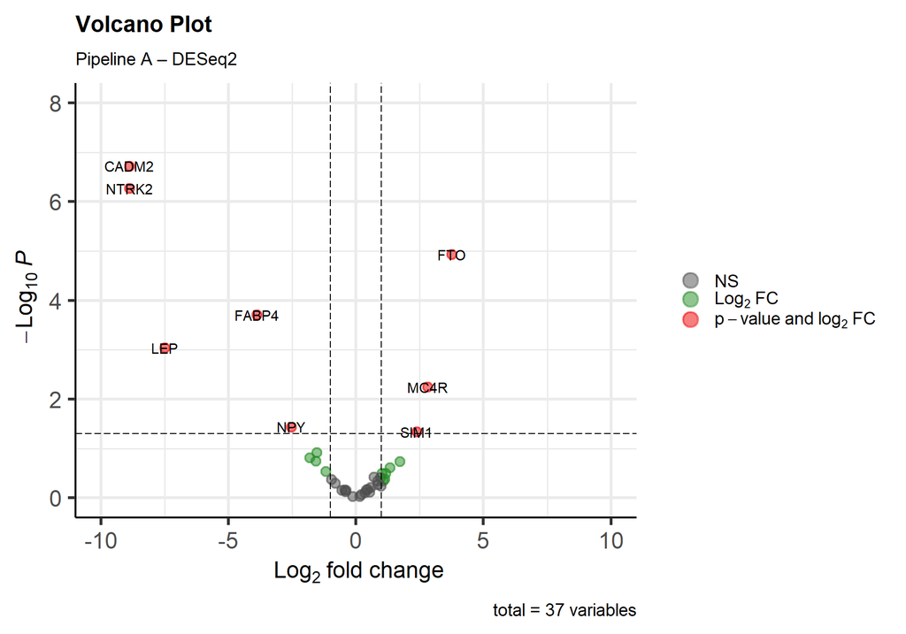

```r
EnhancedVolcano(

  res_df,

  lab = res_df$Gene,

  x = "log2FoldChange",
  y = "pvalue",

  pCutoff = 0.05,
  FCcutoff = 1,

  xlim = c(-10, 10),
  ylim = c(0, 8),

  labSize = 4,
  pointSize = 3,

  title = "Volcano Plot",
  subtitle = "Pipeline A – DESeq2",

  legendPosition = "right"

)
```

# 9. Transformación de datos

```r
vsd <- varianceStabilizingTransformation(
  dds,
  blind = FALSE
)

mat <- assay(vsd)

mat_scaled <- t(scale(t(mat)))

mat_scaled[is.na(mat_scaled)] <- 0

anno_col <- data.frame(
  Condicion = metadata$condition,
  row.names = rownames(metadata)
)
```

# 10. Heatmap completo

# Como el dataset tiene pocos genes (~37), se utiliza una función para estabilizar la varianza.

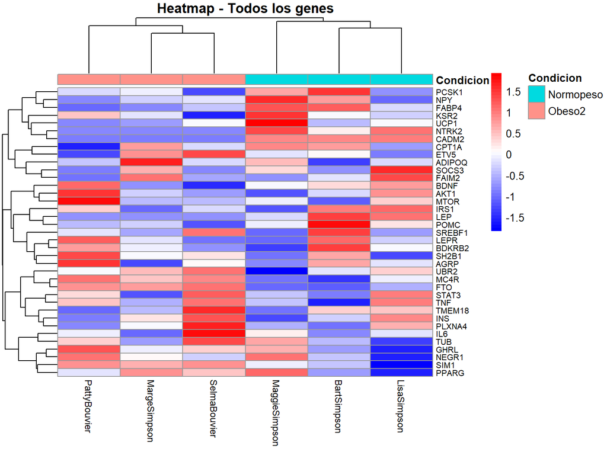

```r
pheatmap(

  mat_scaled,

  cluster_rows = TRUE,
  cluster_cols = TRUE,

  annotation_col = anno_col,

  show_rownames = TRUE,
  show_colnames = TRUE,

  fontsize_row = 8,
  fontsize_col = 9,

  color = colorRampPalette(
    c("blue","white","red")
  )(50),

  main = "Heatmap - Todos los genes"

)
```

# 11. Heatmap comparativo con Pipeline B

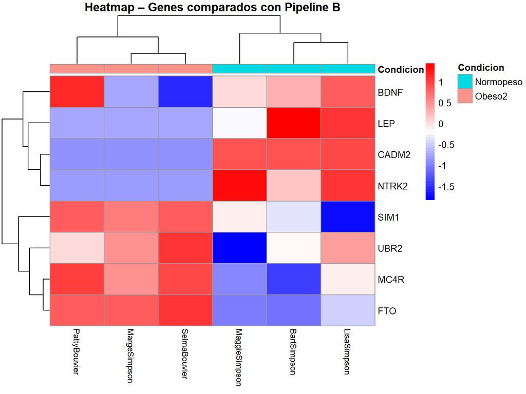

```r
genes_pipelineB <- c(
  "BDNF","CADM2","LEP","NTRK2",
  "MC4R","SIM1","FTO","UBR2"
)

genes_presentes <- genes_pipelineB[
  genes_pipelineB %in% rownames(mat_scaled)
]

mat_pipelineB <- mat_scaled[
  genes_presentes,
]

pheatmap(

  mat_pipelineB,

  cluster_rows = TRUE,
  cluster_cols = TRUE,

  annotation_col = anno_col,

  show_rownames = TRUE,
  show_colnames = TRUE,

  fontsize_row = 10,
  fontsize_col = 9,

  color = colorRampPalette(
    c("blue","white","red")
  )(50),

  main = "Heatmap – Genes comparados con Pipeline B"

)
```

# 12. PCA

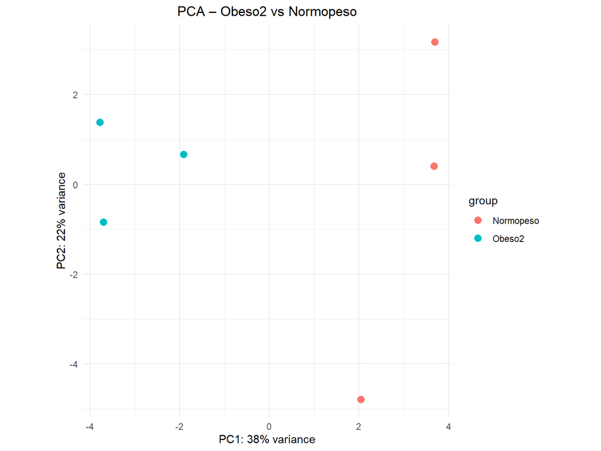

```r
plotPCA(
  vsd,
  intgroup = "condition"
) +

theme_minimal() +

ggtitle("PCA – Obeso2 vs Normopeso") +

theme(
  plot.title = element_text(hjust = 0.5)
)
```